# Question

This question asks you to find [one-sided limits](https://en.wikipedia.org/wiki/One-sided_limit).

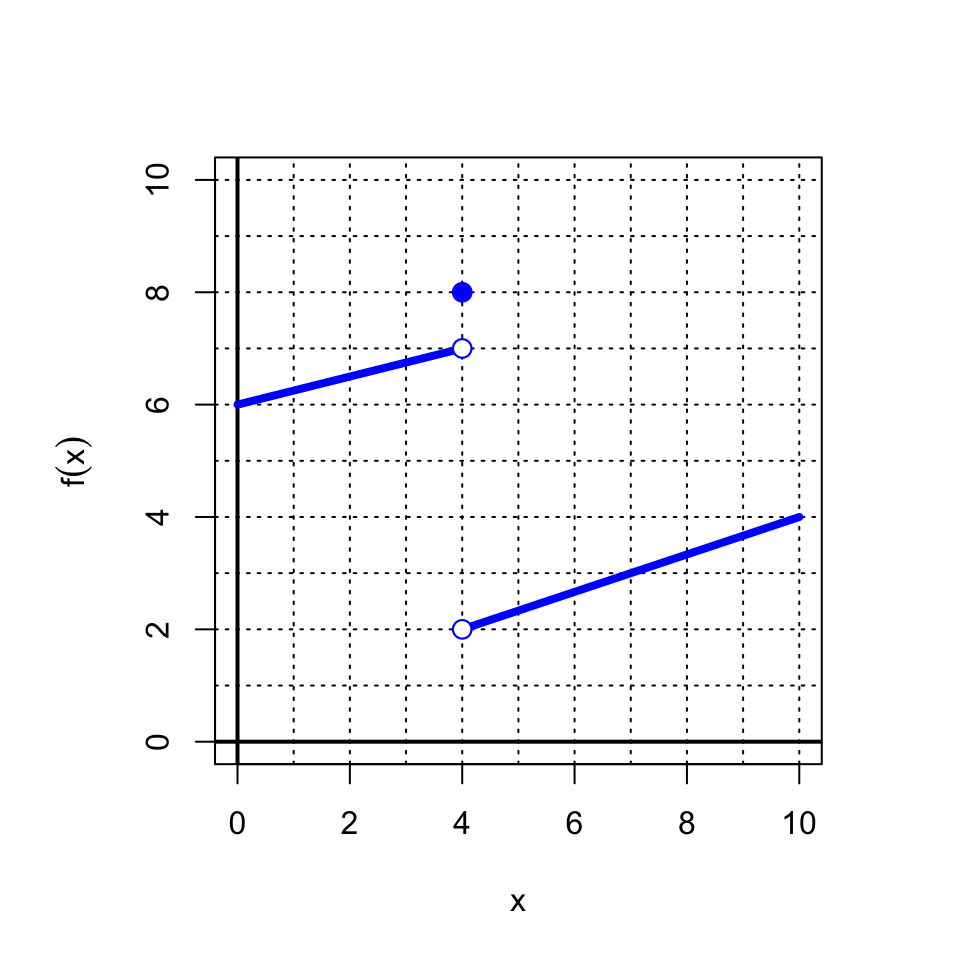

- Find $f(4)$: ##ANSWER1##
- Find $\lim\limits_{x\to4^{-}}f(x)$: ##ANSWER2##
- Find $\lim\limits_{x\to4^{+}}f(x)$: ##ANSWER3##

## Answerlist

- 0
- 1
- 2
- 3
- 4
- 5
- 6
- 7
- 8
- 9
- 10
- 0
- 1
- 2
- 3
- 4
- 5
- 6
- 7
- 8
- 9
- 10
- 0
- 1
- 2
- 3
- 4
- 5
- 6
- 7
- 8
- 9
- 10

# Solution

To find $f(4)$, you put your pencil at the origin, then move right until $x=4$. Then, you go up until you hit the function (the solid dot in this case). Find the vertical coordinate of that spot. $f(4)=8$.

To find the limit as $x$ approaches $4$ from the left, imagine walking along the curve from left to right. Just before $x=4$, it seems the path is heading to a vertical coordinate of 7. So, $\lim\limits_{x\to4^{-}}f(x) = 7$.

To find the limit as $x$ approaches $4$ from the right, imagine walking along the curve from right to left Just before $x=4$, it seems the path is heading to a vertical coordinate of 2. So, $\lim\limits_{x\to4^{+}}f(x) = 2$.

(Just FYI:) Since the limit from the left does not equal the limit from the right, the overall limit does not exist.

$$\lim\limits_{x\to4^{-}}f(x) \ne
\lim\limits_{x\to4^{+}}f(x) ~~~~ \to ~~~~
\lim\limits_{x\to4}f(x)=\text{DNE}$$

# Meta-information

extype: cloze exclozetype: schoice|schoice|schoice exsolution: 00000000100|00000001000|00100000000 exname: graph_limits